# Manipulación y análisis descriptivo de datos con tidyverse (parte II)

Resúmenes, tablas cruzadas y gráficos para describir una encuesta

Jesús Martín Godoy

godoy@ugr.es

Departamento de Sociología  
Universidad de Granada

Nadia Adelshina

anadia@ugr.es

Departamento de Ciencia Política y de la Administración  
Universidad de Granada

## Plan de la sesión

- **De dónde partimos:** retomamos la tabla preparada en la sesión 2 y la pregunta de partida: ¿quién ve más televisión, jóvenes o mayores?
- **Explorar antes de analizar:** cuántos casos válidos tenemos, qué valores llaman la atención y qué respuestas *no* son `NA`.
- **Describir una variable:** frecuencias y porcentajes de una variable categórica; media, mediana y dispersión de una variable numérica.
- **Comparar grupos:** resúmenes para todos los grupos de edad a la vez con `group_by()` y `summarise()`.
- **Cruzar dos variables categóricas:** estado civil según la edad, en formato largo y ancho, y su gráfico.

## Repaso de la sesión 2: dónde lo dejamos

Lo que ya tenemos preparado y cómo lo usaremos hoy:

1. Una tabla de trabajo limpia

dim(datos_trabajo) [1] 11299 4

`edad`, `horas_tv`, `tv_minutos` y `grupo_edad` de las personas con ambas respuestas.

**Hoy:** la describimos y comparamos sus grupos.

2. Un archivo para no repetir la limpieza

write_csv(datos_trabajo, "outputs/encuesta_preparada.csv")

El CSV original de `datos/` sigue intacto.

**Hoy:** empezamos leyendo este archivo.

3. Una selección de dos grupos

nrow(datos_comparacion) [1] 4100

Las personas de «18–29» y de «65 o más», seleccionadas con `%in%`.

**Hoy:** la usaremos en el ejercicio final.

4. Una primera respuesta, grupo a grupo

round(mean(jovenes$tv_minutos)) [1] 167 round(mean(mayores$tv_minutos)) [1] 222

**Hoy:** calcularemos todos los grupos a la vez.

# Empezamos

## Al iniciar RStudio

1. **Abre tu proyecto.** Haz doble clic en `taller_R.Rproj`, dentro de la carpeta `taller_R`.
2. **Abre tu documento de trabajo** de la sesión anterior (`.qmd` o script).
3. **Carga el paquete y las dos tablas.** La encuesta completa y la tabla que guardamos en la sesión 2:

```r
library(tidyverse)
datos <- read_csv("datos/encuesta_social.csv")
datos_trabajo <- read_csv("outputs/encuesta_preparada.csv")
```

> *Nota:* si no encuentras `outputs/encuesta_preparada.csv`, ejecuta el código de la diapositiva siguiente para volver a crearlo.

## Si no tienes la tabla de la sesión 2

Este bloque repite **todos los pasos de la sesión 2** y vuelve a guardar el archivo:

```r
datos_trabajo <- datos |>
  drop_na(age, tvhours) |>
  select(age, tvhours) |>
  rename(edad = age, horas_tv = tvhours) |>
  filter(edad >= 18) |>
  arrange(edad) |>
  mutate(tv_minutos = horas_tv * 60,
         grupo_edad = case_when(edad <= 29 ~ "18–29",
                                edad <= 44 ~ "30–44",
                                edad <= 64 ~ "45–64",
                                TRUE       ~ "65 o más")) |>
  write_csv("outputs/encuesta_preparada.csv")

datos_comparacion <- datos_trabajo |>
  filter(grupo_edad %in% c("18–29", "65 o más"))
```

> *Nota:* `write_csv()` guarda el archivo y, además, devuelve la tabla, que queda guardada en `datos_trabajo`.

## Qué funciones vamos a usar hoy

Todas se cargan con `library(tidyverse)`. Las agrupamos según lo que hacen:

Resumir

- `count()` · Contar casos por categoría.
- `summarise()` · Calcular medias, medianas…
- `group_by()` · Repetir el cálculo en cada grupo.
- `if_else()` · Clasificar según una condición.

Organizar

- `factor()` · Convertir texto en categorías.
- `fct_infreq()` · Ordenar categorías por frecuencia.
- `fct_recode()` · Cambiar el nombre de las categorías.
- `across()` · Aplicar un cambio a varias columnas.
- `pivot_wider()` · Pasar una tabla a formato ancho.

Visualizar

- `ggplot()` · Preparar el lienzo del gráfico.
- `geom_histogram()` · Histograma.
- `geom_boxplot()` · Diagramas de caja.
- `geom_col()` · Barras con valores ya calculados.

> *Nota:* `count()`, `summarise()`, `group_by()`, `if_else()`, `across()` son de **dplyr**; `fct_infreq()` y `fct_recode()` de **forcats**; `pivot_wider()` de **tidyr**, y los gráficos, de **ggplot2**. `factor()` es de R base.

# Explorar antes de analizar

## ¿Cuántas personas entran en cada análisis?

`summarise()` resume toda la tabla en **una sola fila**. Dentro escribimos `nombre = cálculo`:

```r
datos |> summarise(
  casos = n(),
  edad_valida = sum(!is.na(age)),
  tv_valida = sum(!is.na(tvhours)),
  ambas_validas = sum(!is.na(age) & !is.na(tvhours)))
```

```
# A tibble: 1 × 4
  casos edad_valida tv_valida ambas_validas
  <int>       <int>     <int>         <int>
1 21483       21407     11337         11299
```

- `n()` cuenta todas las filas. `!is.na(tvhours)` vale `TRUE` cuando **sí** hay respuesta, y `sum()` cuenta esos `TRUE`.

**¿Qué columna indica cuántos casos tiene una comparación de televisión por edad?**

## ¿Qué valores merecen una segunda mirada?

```r
datos_trabajo |> summarise(
  edad_min = min(edad),
  edad_max = max(edad),
  tv_min = min(horas_tv),
  tv_max = max(horas_tv))
```

```
# A tibble: 1 × 4
  edad_min edad_max tv_min tv_max
     <dbl>    <dbl>  <dbl>  <dbl>
1       18       89      0     24
```

**En pareja.** ¿Os parece creíble un máximo de 24 horas diarias de televisión? ¿Qué comprobaríais antes de decidir si lo excluís?

> *Nota:* aquí no necesitamos `na.rm = TRUE`, porque en `datos_trabajo` ya no hay `NA`. Cero horas es una respuesta válida.

## Cuidado: «No answer» no es `NA`

`count()` cuenta cuántas personas hay en cada categoría. Con `sort = TRUE`, de más a menos:

```r
datos |> count(marital, sort = TRUE)
```

```
# A tibble: 6 × 2
  marital           n
  <chr>         <int>
1 Married       10117
2 Never married  5416
3 Divorced       3383
4 Widowed        1807
5 Separated       743
6 No answer        17
```

¿Qué vemos?

- **«No answer»** aparece como una **categoría más**, escrita como texto.
- Para R no es un valor ausente: `drop_na()` **no** la elimina.
- Si no queremos analizarla, hay que excluirla con `filter()`:

`filter(marital != "No answer")`

# Análisis univariado: una variable

## Variables categóricas: de texto a factor

Una variable categórica de texto (`<chr>`) se ordena **alfabéticamente**. Como **factor** (`<fct>`), sus categorías (*levels*) tienen un orden fijo que respetan las tablas y los gráficos.

### Una variable

```r
datos_trabajo <- datos_trabajo |>
  mutate(grupo_edad = factor(grupo_edad))

levels(datos_trabajo$grupo_edad)
```

```
[1] "18–29"    "30–44"    "45–64"    "65 o más"
```

### Varias variables a la vez

```r
datos |>
  mutate(across(c(marital, race),
                factor)) |>
  select(marital, race) |> glimpse()
```

```
Rows: 21,483
Columns: 2
$ marital <fct> Never married, Divorced, Widowed, Never married, Divorced,…
$ race    <fct> White, White, White, White, White, White, White, White, Wh…
```

> *Nota:* `factor()` ordena los niveles alfabéticamente; aquí coincide con el orden de edad. `across()` aplica la misma función a todas las columnas de `c()`.

## Frecuencias y porcentajes

Contamos las personas de cada grupo de edad y calculamos el **porcentaje** sobre el total:

```r
datos_trabajo |>
  count(grupo_edad) |>
  mutate(porcentaje = round(100 * n / sum(n), 1))
```

```
# A tibble: 4 × 3
  grupo_edad     n porcentaje
  <fct>      <int>      <dbl>
1 18–29       2026       17.9
2 30–44       3389       30
3 45–64       3810       33.7
4 65 o más    2074       18.4
```

- `n` es el número de personas de cada grupo; `sum(n)`, el total de la tabla (11.299).

**¿Qué grupo aporta más casos al análisis?** Indica su frecuencia y su porcentaje.

## Una variable numérica: centro y dispersión

```r
datos_trabajo |> summarise(
  casos = n(),
  media = mean(horas_tv),
  mediana = median(horas_tv),
  desviacion = sd(horas_tv),
  minimo = min(horas_tv),
  maximo = max(horas_tv))
```

```
# A tibble: 1 × 6
  casos media mediana desviacion minimo maximo
  <int> <dbl>   <dbl>      <dbl>  <dbl>  <dbl>
1 11299  2.98       2       2.59      0     24
```

**Media.** Promedio de horas diarias.

**Mediana.** La mitad de las personas ve esa cantidad o menos.

**Desviación típica.** Cuánto se alejan las respuestas de la media.

## La forma de la distribución: histograma

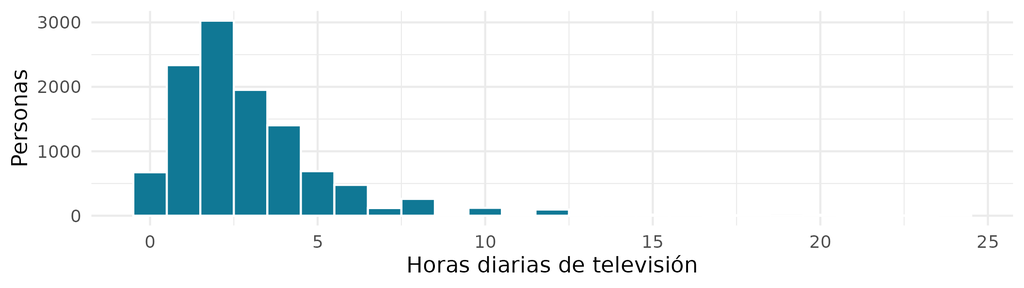

```r
ggplot(datos_trabajo, aes(x = horas_tv)) +
  geom_histogram(binwidth = 1, fill = "#107895", colour = "white") +
  labs(x = "Horas diarias de televisión", y = "Personas") +
  theme_minimal(base_size = 17)
```

Cada barra cuenta las personas que ven **esa cantidad de horas**. ¿Hacia qué lado se alarga la distribución?

# Análisis bivariado: comparar grupos

## De grupo en grupo a todos los grupos a la vez

### En la sesión 2: grupo a grupo

```r
jovenes <- datos_trabajo |>
  filter(grupo_edad == "18–29")
mean(jovenes$tv_minutos)

mayores <- datos_trabajo |>
  filter(grupo_edad == "65 o más")
mean(mayores$tv_minutos)
```

Hay que repetir el código **para cada grupo**.

### Hoy: con `group_by()` + `summarise()`

```r
resumen_tv <- datos_trabajo |>
  group_by(grupo_edad) |>
  summarise(casos = n(),
            media_min = mean(tv_minutos),
            mediana_min = median(tv_minutos),
            desviacion_min = sd(tv_minutos)) |>
  arrange(desc(media_min))
```

**Cómo leerlo:** «Agrupa por edad **y después** resume cada grupo».

## Leer el resultado: ¿cuánto difieren los grupos?

```r
resumen_tv
```

```
# A tibble: 4 × 5
  grupo_edad casos media_min mediana_min desviacion_min
  <fct>      <int>     <dbl>       <dbl>          <dbl>
1 65 o más    2074      222.         180           159.
2 45–64       3810      184.         120           161.
3 18–29       2026      167.         120           155.
4 30–44       3389      155.         120           140.
```

1. **Compara.** ¿Qué grupo tiene la media más alta? ¿Y la más baja?
2. **Cuantifica.** ¿Cuántos minutos diarios separan esos dos grupos?
3. **Contrasta.** ¿Las medianas ordenan los grupos igual que las medias?

## Comparar distribuciones: diagramas de caja

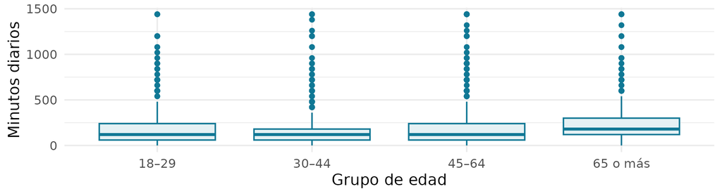

```r
ggplot(datos_trabajo, aes(x = grupo_edad, y = tv_minutos)) +
  geom_boxplot(fill = "#e5f1f4", colour = "#107895") +
  labs(x = "Grupo de edad", y = "Minutos diarios") + theme_minimal(base_size = 17)
```

La línea central marca la **mediana** y la caja abarca la **mitad central** de las respuestas. ¿Cuánto se solapan las cajas?

## ¿Por encima o por debajo de la media?

Con `if_else()` clasificamos a cada persona según una **condición**: «si se cumple, esto; si no, lo otro».

```r
media_global <- mean(datos_trabajo$tv_minutos)

datos_trabajo <- datos_trabajo |>
  mutate(respecto_media = if_else(
    tv_minutos > media_global,
    "Por encima de la media",
    "En la media o por debajo"))
```

**Anticipa.** La media es de 178,9 minutos. ¿Qué etiqueta recibe alguien que ve 3 horas (180 minutos)? ¿Y alguien que ve 0?

## Porcentajes dentro de cada grupo

Contamos por **dos variables** y calculamos el porcentaje sobre el total **de cada grupo de edad**:

```r
datos_trabajo |>
  count(grupo_edad, respecto_media) |>
  group_by(grupo_edad) |>
  mutate(porcentaje = round(100 * n / sum(n), 1)) |>
  ungroup()
```

```
# A tibble: 8 × 4
  grupo_edad respecto_media               n porcentaje
  <fct>      <chr>                    <int>      <dbl>
1 18–29      En la media o por debajo  1181       58.3
2 18–29      Por encima de la media     845       41.7
3 30–44      En la media o por debajo  2088       61.6
4 30–44      Por encima de la media    1301       38.4
5 45–64      En la media o por debajo  2023       53.1
6 45–64      Por encima de la media    1787       46.9
7 65 o más   En la media o por debajo   746       36
8 65 o más   Por encima de la media    1328       64
```

> *Nota:* con `group_by()`, `sum(n)` suma solo los casos del grupo de edad. Es el equivalente a los **porcentajes de fila** de SPSS.

# Dos variables categóricas: estado civil y edad

## Preparar la tabla del cruce

`datos_trabajo` no incluye el estado civil. Creamos **otra tabla** a partir de `datos`, con los verbos de la sesión 2:

```r
datos_civil <- datos |>
  drop_na(age) |>
  filter(marital != "No answer") |>
  select(age, marital) |>
  rename(edad = age, estado_civil = marital) |>
  mutate(grupo_edad = case_when(edad <= 29 ~ "18–29",
                                edad <= 44 ~ "30–44",
                                edad <= 64 ~ "45–64",
                                TRUE       ~ "65 o más"),
         grupo_edad = factor(grupo_edad))
```

Conservamos **21.397 personas**: aquí no necesitamos las horas de televisión, así que no excluimos a quien no respondió a esa pregunta.

## Etiquetas en español con `fct_recode()`

`fct_recode()` cambia el **nombre de las categorías** de un factor sin tocar los datos originales:

```r
datos_civil <- datos_civil |>
  mutate(estado_civil = fct_recode(estado_civil,
           "En matrimonio"         = "Married",
           "Sin matrimonio previo" = "Never married",
           "Divorcio"              = "Divorced",
           "Viudedad"              = "Widowed",
           "Separación"            = "Separated"),
         estado_civil = fct_infreq(estado_civil))

levels(datos_civil$estado_civil)
```

```
[1] "En matrimonio"         "Sin matrimonio previo" "Divorcio"
[4] "Viudedad"              "Separación"
```

> *Nota:* el orden es `"nuevo" = "antiguo"`: primero la etiqueta que queremos y después la que aparece en los datos. `fct_infreq()` ordena las categorías de la más frecuente a la menos frecuente.

## La tabla cruzada en formato largo

```r
cruce_civil <- datos_civil |>
  count(grupo_edad, estado_civil) |>
  group_by(grupo_edad) |>
  mutate(porcentaje = round(100 * n / sum(n), 1)) |>
  ungroup()

cruce_civil |> print(n = 6)
```

```
# A tibble: 20 × 4
  grupo_edad estado_civil              n porcentaje
  <fct>      <fct>                 <int>      <dbl>
1 18–29      En matrimonio           938       24.6
2 18–29      Sin matrimonio previo  2638       69.1
3 18–29      Divorcio                144        3.8
4 18–29      Viudedad                  6        0.2
5 18–29      Separación               89        2.3
6 30–44      En matrimonio          3448       53.6
# ℹ 14 more rows
```

Una fila por **combinación** de grupo de edad y estado civil: 20 filas (4 grupos × 5 estados civiles).

## Del formato largo al formato ancho

Formato largo

Una fila por **combinación** de categorías.

| grupo | estado | % |
| --- | --- | --- |
| 18–29 | En matrimonio | 24.6 |
| 18–29 | Sin matr. previo | 69.1 |
| … | … | … |

Mejor para **R y los gráficos**.

Formato ancho

Una fila por **grupo de edad**; una columna por **estado civil**.

| grupo | En matrimonio | Sin matr. previo | … |
| --- | --- | --- | --- |
| 18–29 | 24.6 | 69.1 | … |
| 30–44 | 53.6 | 25.7 | … |

Mejor para **leer y comparar**, como una tabla de SPSS.

`pivot_wider()` convierte la tabla larga en ancha: `names_from` indica de dónde salen **los nombres de las columnas** y `values_from`, **los valores de las celdas**.

## La tabla cruzada en formato ancho

```r
cruce_civil |>
  select(grupo_edad, estado_civil, porcentaje) |>
  pivot_wider(names_from = estado_civil,
              values_from = porcentaje)
```

```
# A tibble: 4 × 6
  grupo_edad `En matrimonio` `Sin matrimonio previo` Divorcio Viudedad Separación
  <fct>                <dbl>                   <dbl>    <dbl>    <dbl>      <dbl>
1 18–29                 24.6                    69.1      3.8      0.2        2.3
2 30–44                 53.6                    25.7     14.9      1.1        4.6
3 45–64                 55.1                    12.6     23.3      5.2        3.9
4 65 o más              43.6                     5       14.6     35          1.8
```

**Lee la tabla por filas.** ¿En qué grupo de edad es más frecuente «En matrimonio»? ¿Dónde aparece más la viudedad?

> *Nota:* cada fila suma 100 %. Los nombres con espacios aparecen entre comillas invertidas (`` `Sin matrimonio previo` ``).

## El cruce en un gráfico de barras

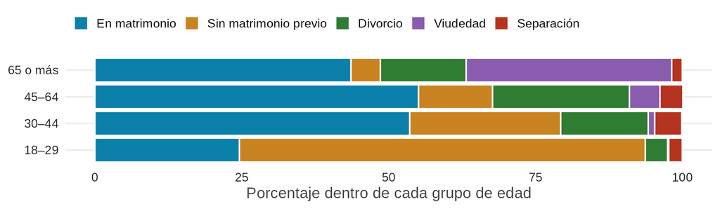

```r
ggplot(cruce_civil, aes(x = porcentaje, y = grupo_edad, fill = estado_civil)) +
  geom_col(position = position_stack(reverse = TRUE), colour = "white") +
  scale_fill_manual(values = colores_civil) +
  labs(x = "Porcentaje dentro de cada grupo de edad", y = NULL) +
  tema_taller
```

Cada barra suma **100 %**: muestra la composición por estado civil de **un grupo de edad**.

## Interpretar con cuidado

¿Quién responde?

Cada análisis usa **sus casos válidos**: 11.299 en la televisión; 21.397 en el estado civil.

Varios años juntos

Los datos suman encuestas de **2000 a 2014**. Para estudiar cambios, habría que separar por `year`.

Sin ponderar

Las encuestas reales incluyen un **peso**. `count()` lo admite con el argumento `wt`.

Asociación, no causa

La edad **va unida** al ciclo de vida y a la generación: describimos, no explicamos.

# Practicamos

## Tu turno: partido político según la edad

Repite el cruce con **`partyid`** (identificación partidista) en lugar del estado civil:

1. **Explora.** Ejecuta `datos |> count(partyid, sort = TRUE)`. ¿Qué categorías no son partidos?
2. **Agrupa.** Con `case_when()` y `%in%`, crea `bloque`: «Demócrata», «Independiente» y «Republicano». El resto queda como `NA`.
3. **Cruza.** Calcula los porcentajes de cada bloque **dentro de cada grupo de edad** y pásalos a formato ancho.
4. **Escribe** dos frases: ¿qué bloque crece con la edad y cuál disminuye?

> *Pista:* `partyid %in% c("Strong democrat", "Not str democrat") ~ "Demócrata"`. Después, `drop_na(bloque)`.

## Para practicar en casa

1. La edad según el estado civil

Con `datos_civil`, calcula por `estado_civil` el número de casos, la media, la mediana, el mínimo, el máximo y la desviación típica de la edad. Ordena de mayor a menor media.

2. Comparar los dos extremos

Con `datos_comparacion`, repite el resumen de `group_by()` + `summarise()` de los minutos de televisión. ¿Obtienes las mismas medias que en la sesión 2?

3. Guardar tus resultados

Guarda la tabla ancha con `write_csv()` en `outputs/` y el gráfico con `ggsave("outputs/estado_civil_edad.png")`, justo después de dibujarlo.

## Hemos aprendido…

- **Contar casos válidos** con `summarise()`, `n()` y `sum(!is.na())`: cada análisis tiene su propio número de casos.
- **Revisar las categorías** con `count()`: «No answer» es texto, no `NA`, y se excluye con `filter()`.
- **Convertir en factor** con `factor()` y `across()`; ordenar y renombrar categorías con `fct_infreq()` y `fct_recode()`.
- **Describir una variable:** frecuencias y porcentajes; media, mediana y desviación típica; histograma.
- **Comparar grupos** con `group_by()` + `summarise()`, diagramas de caja e `if_else()`.
- **Cruzar dos variables categóricas:** porcentajes de fila, `pivot_wider()` y barras apiladas con `geom_col()`.

# Anexo: chuleta de funciones

## Chuleta · Sesión 2: preparar los datos

Importar y mirar

| Función | Para qué |
| --- | --- |
| `read_csv("datos/…")` | Importar un CSV |
| `glimpse(datos)` | Ver variables y tipos |
| `dim()`, `nrow()` | Dimensiones y filas |
| `head(datos, n = 4)` | Primeras filas |
| `distinct()` | Filas o categorías únicas |
| `mean(x, na.rm = TRUE)` | Media sin los `NA` |

Filas y columnas

| Función | Para qué |
| --- | --- |
| `drop_na(age, tvhours)` | Quitar filas con `NA` |
| `filter(edad >= 18)` | Quedarse con **filas** |
| `select(age, tvhours)` | Quedarse con **columnas** |
| `rename(edad = age)` | Cambiar el nombre de columnas |
| `arrange(desc(edad))` | Ordenar filas |
| `%in% c("…", "…")` | Una de varias categorías |

Crear y guardar

| Función | Para qué |
| --- | --- |
| `mutate(nueva = …)` | Crear o cambiar una columna |
| `case_when(cond ~ valor)` | Recodificar en categorías |
| `\|>` | Encadenar pasos |
| `<-` | Guardar el resultado |
| `write_csv(tabla, "outputs/…")` | Guardar en un CSV |
| `dir.create("outputs")` | Crear una carpeta |

## Chuleta · Sesión 3: describir y comparar

Resumir

| Función | Para qué |
| --- | --- |
| `summarise(media = mean(x))` | Resumir en una fila |
| `n()` | Número de casos (dentro de `summarise()`) |
| `count(var, sort = TRUE)` | Frecuencias |
| `group_by(var)` | Calcular por grupos |
| `ungroup()` | Quitar la agrupación |
| `median()`, `sd()`, `min()`, `max()` | Estadísticos |

Categorías y tablas

| Función | Para qué |
| --- | --- |
| `factor()`, `levels()` | Crear un factor; ver sus niveles |
| `across(c(a, b), factor)` | Lo mismo en varias columnas |
| `fct_infreq()` | Ordenar por frecuencia |
| `fct_recode("nuevo" = "antiguo")` | Renombrar categorías |
| `if_else(cond, "sí", "no")` | Dos categorías |
| `pivot_wider(names_from, values_from)` | Tabla ancha |

Gráficos

| Función | Para qué |
| --- | --- |
| `ggplot(datos, aes(x, y))` | Lienzo y ejes |
| `+` | Añadir capas |
| `geom_histogram()` | Histograma |
| `geom_boxplot()` | Diagramas de caja |
| `geom_col()` | Barras con valores ya calculados |
| `labs()`, `theme_minimal()` | Títulos y aspecto |

## Funciones que se confunden (I): filas, columnas y resúmenes

| Se confunden | En qué se diferencian | Cómo evitarlo |
| --- | --- | --- |
| `filter()` y `select()` | `filter()` elige **filas** (personas); `select()`, **columnas** (variables). | Filtrar con condición (`edad >= 18`); seleccionar con nombres (`edad`). |
| `filter()` y `drop_na()` | `drop_na()` solo quita `NA`; «No answer» u otros textos se quitan con `filter()`. | Mirar antes las categorías con `count()`. |
| `mutate()` y `summarise()` | `mutate()` **conserva** todas las filas y añade una columna; `summarise()` las **reduce** a una por grupo. | ¿Quieres un dato por persona o por grupo? |
| `summarise()` y `summary()` | `summarise()` (dplyr) devuelve una tabla con lo que pidas; `summary()` (R base) da un resumen automático. | En una cadena con `\|>`, `summarise()`. |
| `count()`, `n()` y `nrow()` | `count(var)` da una tabla de frecuencias; `n()` cuenta dentro de `summarise()`; `nrow()` cuenta las filas de una tabla. | `n()` siempre va dentro de otra función. |

## Funciones que se confunden (II): símbolos

| Se confunden | En qué se diferencian | Cómo evitarlo |
| --- | --- | --- |
| `=` y `==` | `=` asigna un nombre o un argumento (`edad = age`); `==` **compara** (`edad == 18`). | Dentro de `filter()`, siempre `==`. |
| `==` y `%in%` | `== c("a", "b")` compara fila a fila y da resultados erróneos **sin avisar**; `%in%` comprueba si el valor está en la lista. | Una categoría: `==`. Varias: `%in%`. |
| `!=` y `!x %in%` | `!=` excluye una categoría; para excluir varias, el `!` va **delante** de la variable. | `filter(!partyid %in% c("No answer", "Don't know"))` |
| `\|>` y `+` | `\|>` encadena pasos con datos; `+` añade capas a un gráfico de ggplot2. | Después de `ggplot()`, solo `+`. |
| `NA` y `"NA"` | `NA` (sin comillas) es un valor ausente; `"NA"` o `"No answer"` son texto. | `is.na(x)` para `NA`; `x == "No answer"` para el texto. |
| `"18–29"` y `"18-29"` | El guion largo y el corto son caracteres distintos: el filtro devuelve 0 filas. | Copiar las etiquetas con `levels()` o `distinct()`. |

## Funciones que se confunden (III): recodificar y ordenar

| Se confunden | En qué se diferencian | Cómo evitarlo |
| --- | --- | --- |
| `rename()`, `fct_recode()` y `case_when()` | `rename(nuevo = antiguo)` cambia el nombre de una **columna**; `fct_recode("nuevo" = "antiguo")`, el de una **categoría**; `case_when(condición ~ "valor")` crea categorías a partir de condiciones. | Lo nuevo va a la izquierda del `=`; en `case_when()`, la condición va a la izquierda del `~`. |
| `if_else()` y `case_when()` | `if_else()` crea **dos** categorías; `case_when()`, **dos o más**. | Con tres grupos o más, `case_when()`. |
| `arrange()` y `fct_infreq()` | `arrange()` ordena las **filas** de la tabla; `fct_infreq()` ordena las **categorías** de un factor en tablas y gráficos. | ¿Quieres reordenar personas o etiquetas? |
| `geom_col()`, `geom_bar()` y `geom_histogram()` | `geom_col()` usa valores ya calculados; `geom_bar()` cuenta filas de una variable categórica; `geom_histogram()` agrupa una variable numérica en intervalos. | ¿Tienes ya los porcentajes? `geom_col()`. |
| `pivot_wider()` y `pivot_longer()` | `pivot_wider()` pasa de largo a ancho (para leer); `pivot_longer()`, de ancho a largo (para R y ggplot2). | ggplot2 necesita formato largo. |
| `group_by()` sin `ungroup()` | La agrupación sigue activa y afecta a los cálculos siguientes. | Cerrar siempre con `ungroup()`. |

## Para ir más allá: otras funciones estadísticas

| Para… | Función | Ejemplo con la encuesta |
| --- | --- | --- |
| Cuartiles y rango intercuartílico | `quantile()`, `IQR()` | `quantile(datos_trabajo$horas_tv)` |
| Tabla cruzada rápida (R base) | `table()`, `prop.table()` | `prop.table(table(datos$marital, datos$race), 1)` |
| Correlación entre dos variables numéricas | `cor()`, `cor.test()` | `cor.test(datos_trabajo$edad, datos_trabajo$horas_tv)` |
| Asociación entre dos variables categóricas | `chisq.test()` | `chisq.test(table(datos_civil$grupo_edad, datos_civil$estado_civil))` |
| Diferencia de medias entre dos grupos | `t.test()`, `wilcox.test()` | `t.test(tv_minutos ~ grupo_edad, data = datos_comparacion)` |
| Medias entre tres grupos o más | `aov()` + `summary()` | `summary(aov(tv_minutos ~ grupo_edad, data = datos_trabajo))` |
| Regresión lineal | `lm()` + `summary()` | `summary(lm(horas_tv ~ edad, data = datos_trabajo))` |
| Media ponderada | `weighted.mean()` | `weighted.mean(x, w = peso)` |

> *Nota:* todas son de R base. Paquetes útiles que hay que instalar con `install.packages()`: **janitor** (`tabyl()` y `adorn_percentages()` para tablas cruzadas), **skimr** (`skim()` para un resumen de toda la tabla) y **gtsummary** (`tbl_summary()` para tablas de publicación).